# Sketch of the final figures

# **Figure 1:** Phenotypes

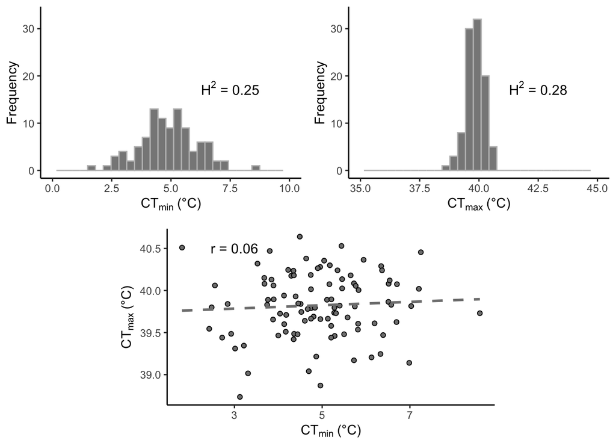

**Figure 1: Distribution of thermal limits in the DGRP.** Histograms of mean phenotypes across 100 DGRP lines for **(A)** CT<sub>min</sub> and **(B)** CT<sub>max</sub>. **(C)** Correlation between line-means of CT<sub>min</sub> and CT<sub>max</sub>.

# **Figure 2:** Manhattan plots

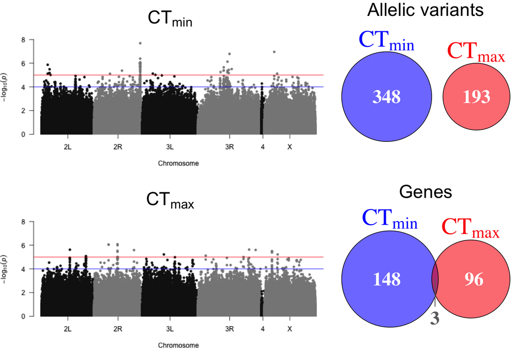

**Figure 2: Results of GWAS to identify polymorphisms associated with thermal tolerance.** Manhattan plots of the results from the GWAS for **(A)** CT<sub>min</sub> and **(B)** CT<sub>max</sub>. The blue line corresponds to p < 1E-4 and the red line corresponds to p < 1E-5. The overlap of **(C)** allelic variants and **(D)** unique genes between CT<sub>min</sub> and CT<sub>max</sub> is also shown.

# **Figure 3:** Effect size & MAF

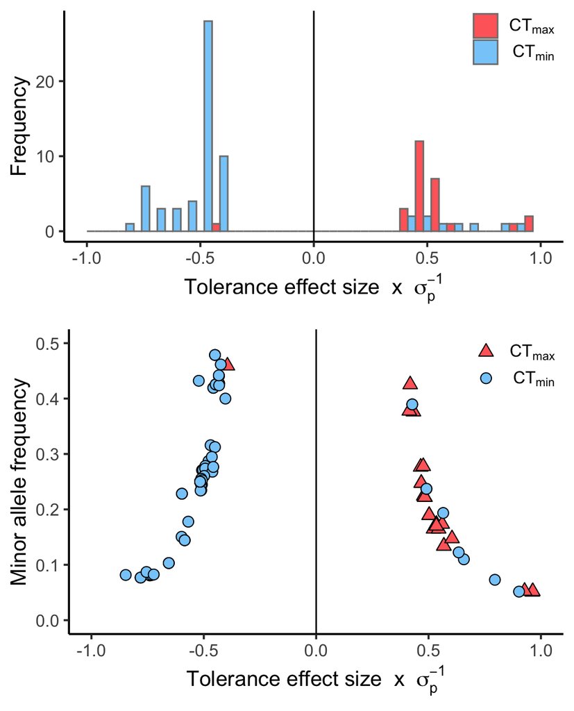

**Figure 3:** Scatter plot of the minor allele frequency versus the tolerance effect size scaled by the phenotypic standard deviation ($\sigma_{p}$) for CT<sub>min</sub> and CT<sub>max</sub>.

Positive values correspond to increased cold tolerance or increased heat tolerance.

# **Figure 4:** DEG & GWAS integration

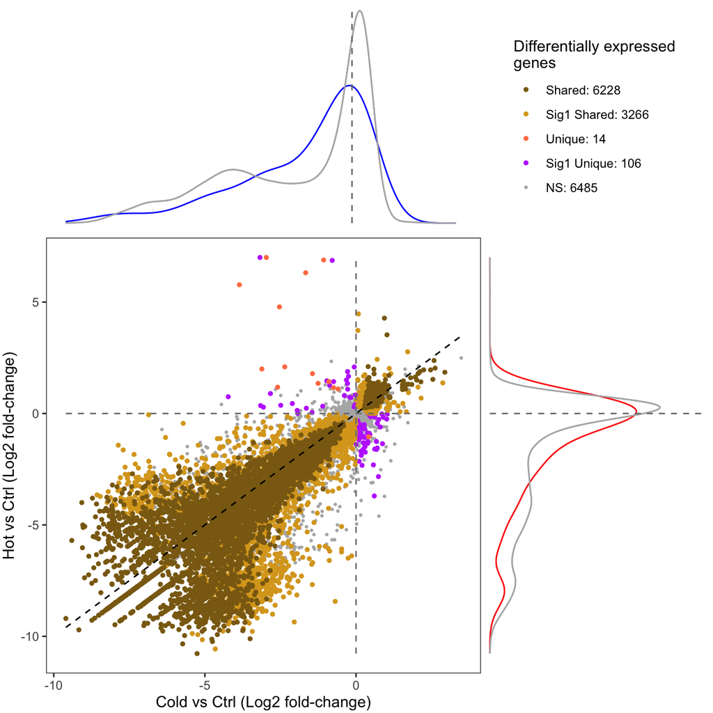

**Figure 4: Scatter plot of the gene expression log-fold change of heat-shock (37°C) and cold-shock (4°C) relative to the 25°C control.** The density plots indicate the density of the genes that are associated with CT<sub>min</sub> (blue) or CT<sub>max</sub> (red) relative to the log fold change expression of all other genes (gray).

# **Figure 5:** ORA for GWAS

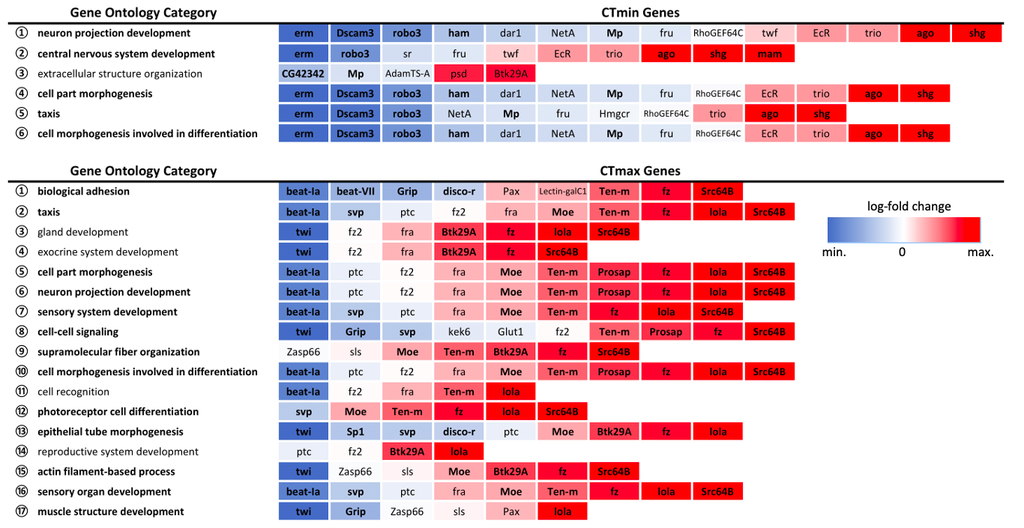

**Figure 5: Expression patterns of GWAS genes within significantly over-represented GO biological process categories.** All expression patterns are expressed relative to the 25°C control. Bolded categories indicate those also over-represented in the full DEG dataset for the corresponding temperature extreme. Bolded genes indicate significant differential gene expression at an FDR < 0.01.

# **Table 1:** Gene counts

| GWAS | Relaxed SNPs | Strict SNPs | Unique genes | DEGs | TFs | DE TFs |
| --- | --- | --- | --- | --- | --- | --- |
| CTmax | 193 | 21 | 99 | 59 | 9 | 9 |
| CTmin | 348 | 53 | 151 | 72 | 12 | 3 |

**Table 1: Counts of the CTmax and CTmin SNPs and integrated expression data.** Counts of Relaxed SNPs (p < 10$^{-4}$), Strict SNPs (p < 10$^{-5}$), unique genes, differentially expressed genes (DEGs; FDR < 0.01), transcription factors (TFs), and differentially expressed transcription factors (DE TFs).

# **Table 2:** Feature counts

| Feature | CTmin | CTmax |
| --- | --- | --- |
| Intron | 171 | 152 |
| Downstream | 40 | 22 |
| Upstream | 35 | 16 |
| Synonymous coding | 31 | 13 |
| 3’ UTR | 11 | 3 |
| Non-synonymous coding | 10 | 7 |
| 5’ UTR | 8 | 2 |
| Exon | 4 | 0 |
| Start gained | 1 | 0 |

**Table 2: Counts of number of SNPs associated with CTmin and CTmax (p < 10-4) that lie within each genomic feature group.**

# **Suplementary Information**

## Thermal Breadth Correlations

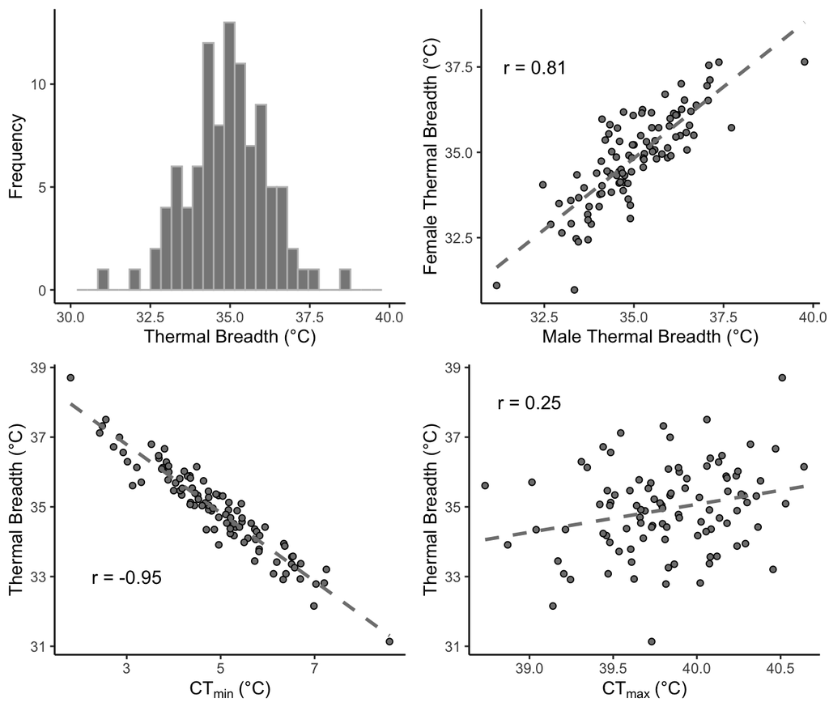

**Supplementary Figure X: (A)** Histograms of mean phenotypes across 100 DGRP lines for thermal breadth. **(B)** Correlation between sex-means for thermal breadth. Correlation between line-means of **(C)** thermal breadth and CT<sub>min</sub> and **(D)** thermal breadth and CT<sub>max</sub>.

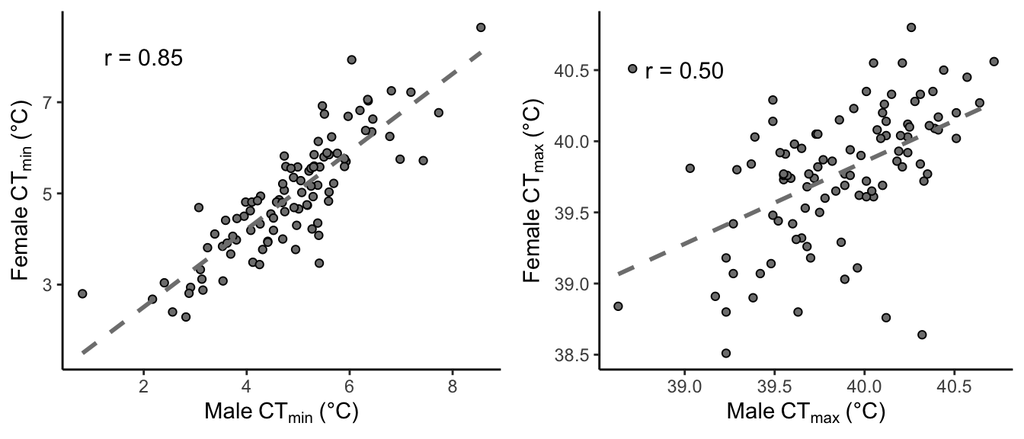

**Supplementary Figure X:** Correlation between sex-means for **(A)** CT<sub>min</sub> and **(B)** CT<sub>max</sub>.

## Links to download supplementary tables

[ORA GWAS & DEG Tables](https://tsoleary.github.io/rna_seq/cahan/results/GO_results_files/ora_gwas_deg_suppl.xlsx)

[DEG Results & Tables](https://tsoleary.github.io/rna_seq/cahan/results/deg_suppl_info.xlsx)